# My title

### **A Empirical Appendix**

#### **A.1 Descriptive statistics**

Here we present additional descriptive statistics on our sample.

Table A.1: Descriptive Statistics: Individual & Job Characteristics

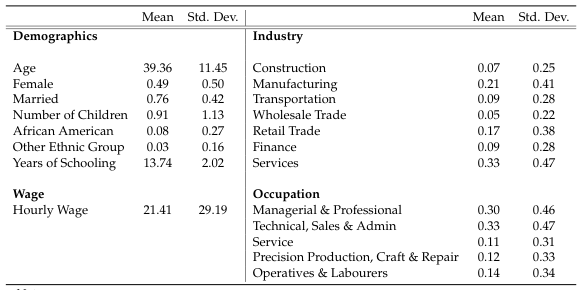

NOTE: complex table shown as an image of the PDF; the text below is a rough machine extraction and may be mis-aligned.

**extracted text (unreliable layout)**

Mean Std Dev. . ; Mean Std Dev. . | Demographics Age 39 .36 11 .45 Female 0 .49 0 .50 Married 0 .76 0 .42 Number of Children 0 .91 1 .13 African American 0 .08 0 .27 Other Ethnic Group 0 .03 0 .16 Years of Schooling 13 .74 2 .02 Wage Hourly Wage 21 .41 29 .19 ; Industry Construction 0 .07 0 .25 Manufacturing 0 .21 0 .41 Transportation 0 .09 0 .28 Wholesale Trade 0 .05 0 .22 Retail Trade 0 .17 0 .38 Finance 0 .09 0 .28 Services 0 .33 0 .47 Occupation Managerial & Professional 0 .30 0 .46 Technical Sales & Admin 0 .33 0 .47 , Service 0 .11 0 .31 Precision Production, Craft & Repair 0 .12 0 .33 Operatives & Labourers 0 .14 0 .34

*Note:* The sample contains 27,832 observations on 5,151 individuals. The sample includes individuals aged 18 to 65,

who are only added to the sample once they join the labour market. They are then dropped from the sample once they leave the labour market and they do not appear again as employed. We restrict our sample to the core PSID sample who are not self-employed or working for the government or in farming related occupations. Lastly, our sample includes individuals which we observe for at least two consecutive waves. Monetary values expressed in 2015 US dollars.

#### **A.2 Robustness Checks**

#### **A.2.1 Major Demographic Groups**

A primary concern with our results could be that they are specific to certain demographic

groups, or perhaps driven by composition effects across groups not captured by the way these

groups are controlled for in our regressions. To show that this is not the case, in Table A.2 we

present results from estimating (2) on key sub-samples. The U-shaped relationship is present

for both men and women, for both single and married individuals, and for those with more

than high school education. The results are relatively consistent across groups, with two no-

table exceptions. Firstly, while the elevated *EN* rate for the top wealth decile still has a positive

and similar point estimate for individuals with a high school diploma or less (column 5), it is

no longer statistically significant, while it is so for other groups. Secondly, the effects are much

stronger for single workers relative to all other groups (column 3).

#### **A.2.2 Life-cycle**

It is well known that older workers have more stable employment, probably because they are

better sorted into good matches, and so a natural question is whether the U-shape relationship

that we found holds only at certain points of the life-cycle. We investigate the robustness

26

Page 27

Table A.2: *EN* transitions in major demographic sub-samples

|  | (1) (2) | (3) (4) | (5) | (6) |
| --- | --- | --- | --- | --- |
|  | Men Women | Single Married | LowEdu . | HighEdu . |
| LowWealth | 0029** 0051*** . . | 0070*** 0028** . . | 0067*** . | 0038*** . |
|  | (0014) (0015) . . | (0020) (0011) . . | (0021) . | (0012) . |
| HighWealth | 0033*** 0036*** . . | 0091*** 0023*** . . | 0014 . | 0034*** . |
|  | (0012) (0013) . . | (0030) (0009) . . | (0016) . | (0011) . |
| Observations | 9949 9102 | 4405 14646 | 7502 | 11549 |
| Individuals | 2489 2341 | 1708 3924 | 2166 | 2955 |
| R2 | 0071 0078 . . | 0090 0052 . . | 0094 . | 0055 . |
| YearFE | Yes Yes | Yes Yes | Yes | Yes |
| I¨ ndividualControls | Yes Yes | Yes Yes | Yes | Yes |
| Industry/Occupation | Yes Yes | Yes Yes | Yes | Yes |

NOTE: table converted from PDF layout to HTML text; cell boundaries are reconstructed. See PDF if exact alignment matters.

* p *<* 0.1, ** p *<* 0.05, *** p *<* 0.01. Standard errors in parentheses.

*Note:* Standard errors are clustered at the individual level. Low Wealth and High

Wealth correspond to the bottom and the top decile of respective wealth distribution. Base group is the remainder of the wealth distribution. Individual controls include age, education, female, race, marital status, number of children, hourly wage, and region, unless excluded due to collinearity with sample split. Industry and occupation dummies are based on 2-digit classifications. High Education are individuals who reported more than 12 years of completed schooling. Low Education individuals are those with 12 or less years of completed schooling.

of the U-shaped pattern to age in Table A.3. We split our sample to consider three different

age groups: 18 *−*34, 35 *−*49 and 50 *−*65. For low wealth agents, the high *EN* risk persists

throughout the life-cycle. The high wealth agents are more likely to experience an *EN*-switch

in the two youngest groups, albeit we do not have enough power to tightly estimate the *High*

*Wealth* coefficient in column (4).

#### **A.2.3 Reverse Causality**

While we control for many worker-level observables, it could be possible that reverse causality

is responsible for the left part of the U-shaped relationship. To see why this could be the case,

suppose that there are two types of workers: type *H* have permanently high *EN* rates, perhaps

due to low productivity, and type *L* have permanently low *EN* rates. Next, let’s assume that

these types are uncorrelated with education, wages, and other observables, since we have

already controlled for these in the main body of the paper. As shown in Section 3.3, making

an *EN* transition causes one’s wealth to fall, plausibly due to running down savings in non-

employment. This could drive a spurious negative correlation between current wealth and a

future *EN* switch through a composition effect: type *H* workers are likely to have low wealth,

because they will have made more *EN* switches in the past, and are likely to make another

*EN* transition in the future due to their permanent type. In this world, there is no causal link

between *low* wealth and future *EN* switches, but a correlation driven by composition.

27

Page 28

Table A.3: Focusing on the Tails of the Wealth Distribution by Age.

|  | WealthwithoutHomeEquity |  |  | WealthwithHomeEquity |  |
| --- | --- | --- | --- | --- | --- |
|  | (1) | (2) | (3) | (4) | (5) (6) |
|  | 18 34 − | 35 49 − | 50 65 − | 18 34 − | 35 49 50 65 − − |
| LowWealth | 0049*** . | 0026* . | 0062** . | 0073*** . | 0035** 0060* . . |
|  | (0015) . | (0016) . | (0028) . | (0015) . | (0016) (0034) . . |
| HighWealth | 0066** . | 0031** . | 0002 . | 0027 . | 0026** 0018 . - . |
|  | (0030) . | (0013) . | (0013) . | (0030) . | (0013) (0013) . . |
| Observations | 7310 | 7681 | 4060 | 7310 | 7681 4060 |
| Individuals | 2789 | 2546 | 1298 | 2789 | 2546 1298 |
| R2 | 0085 . | 0045 . | 0033 . | 0087 . | 0045 0033 . . |
| YearFE | Yes | Yes | Yes | Yes | Yes Yes |
| IndividualControls | Yes | Yes | Yes | Yes | Yes Yes |
| Industry/Occupation | Yes | Yes | Yes | Yes | Yes Yes |

NOTE: table converted from PDF layout to HTML text; cell boundaries are reconstructed. See PDF if exact alignment matters.

* p *<* 0.1, ** p *<* 0.05, *** p *<* 0.01. Standard errors in parentheses.

*Note:* Standard errors are clustered at the individual level. Low Wealth and High

Wealth correspond to the bottom and the top decile of respective wealth distribution. Base group is the remainder of the wealth distribution. Individual controls include age, education, female, race, marital status, number of children, hourly wage, and region. Industry and occupation dummies are based on 2-digit classifications.

The permanent heterogeneity described above should manifest as presence of clusters of

workers differentiated in the incidence of non-employment in their careers. We add various

controls to specification (2) to test this possibility. Firstly, we introduce a dummy *Past EN*

*Transition* which is equal to 1 if a worker has already experienced an *EN* transition. Essentially,

this variable differentiates the first *EN* transition from all of the subsequent ones. Secondly,

we construct a variable *Past Nonemployment Share* which is the ratio of number of interviews

that a worker reported being in non-employment over the number of interviews up to and

including wave *t*.<sup>16</sup> Thirdly, we construct a variable *Total Nonemployment Share* defined as ratio

of interviews the individual reports non-employment over total number of their interviews

in our sample. Compared to *Past Nonemployment Share*, this variable is both backward- and

forward-looking.

We present the results of this exercise in Table A.4. The main finding is that we still find a

statistically significant U-shaped relationship between wealth and *EN* transitions, even with

these extra controls. Overall, our results suggest that part of the likelihood an individual ex-

periences an *EN* transition could indeed be due to their inherent type. We infer this from the

16Note, we define this variable only for observations for which the individual is included in our sample, that is, after their first entry to the labour market and before they permanently leave it. In doing so, we also utilise information prior to 1997.

28

Page 29

Table A.4: Controlling For Past and Future Non-Employment

|  | WealthwithoutHomeEquity |  |  | WealthwithHomeEquity |  |  |
| --- | --- | --- | --- | --- | --- | --- |
|  | (1) | (2) | (3) | (4) | (5) | (6) |
|  | β/SE | β/SE | β/SE | β/SE | β/SE | β/SE |
| LowWealth | 0037*** 0039*** . . |  | 0027*** . | 0052*** 0055*** . . |  | 0041*** . |
|  | (0010) . | (0010) . | (0009) . | (0010) . | (0011) . | (0009) . |
| HighWealth | 0036*** 0035*** . . |  | 0025*** . | 0024*** 0023*** . . |  | 0014* . |
|  | (0008) . | (0009) . | (0008) . | (0008) . | (0009) . | (0008) . |
| Observations | 19051 | 19051 | 19051 | 19051 | 19051 | 19051 |
| Individuals | 4830 | 4830 | 4830 | 4830 | 4830 | 4830 |
| R2 | 0075 . | 0078 . | 0195 . | 0075 . | 0078 . | 0195 . |
| YearFE | Yes | Yes | Yes | Yes | Yes | Yes |
| IndividualControls | Yes | Yes | Yes | Yes | Yes | Yes |
| Industry/Occupation | Yes | Yes | Yes | Yes | Yes | Yes |

NOTE: table converted from PDF layout to HTML text; cell boundaries are reconstructed. See PDF if exact alignment matters.

* p *<* 0.1, ** p *<* 0.05, *** p *<* 0.01. Standard errors in parentheses.

*Note:* Standard errors are clustered at the individual level. Low Wealth and High

Wealth correspond to the bottom and the top decile of respective wealth distribution. Base group is the remainder of the wealth distribution. Individual controls include age, education, female, race, marital status, number of children, hourly wage, and region. Industry and occupation dummies are based on 2- digit classifications.We additionally control for *Past EN Switch* in columns (1) and (4), *Past Nonemployment Share* in columns (2) and (5) and for *Total Nonemployment Share* in columns (3) and (6).

coefficients in Table A.4 being smaller than those estimated in Table 3. However, the U-shaped

pattern is found to be robust to this extension as well.<sup>17</sup>

17We find statistically significant and positive coefficients on the new controls in all three cases (omitted in the Table), suggesting that they indeed capture the differences in individual-specific likelihood of experiencing an *EN* transition. Given objective data limitations this is the best one could do. Trying to address the reverse causality by introducing individual fixed effects is infeasible because of two reasons. Firstly, being in either the *Low Wealth* or *High Wealth* bin is highly persistent. Secondly, we have on average a bit more than 5 observations per individual in the sample.

29

Page 30

### **B Online Appendix**

#### **B.1 Robustness of the U-shape**

In this section we verify the robustness of our key empirical finding on the U-shaped relation-

ship between wealth and likelihood to experience an *EN*-transitions.

#### **B.1.1 Definition of** *EN***: including temporary layoffs**

In the main text, we construct the *EN* variable in a way that eliminates temporary layoffs, both

in the definition of unemployment and also by only looking for incidence of non-employment

for workers who change jobs between interviews. The construction of the *EN* variable as in

the main text therefore emphasizes permanent separations between employers and workers.

Here we show that our main finding is robust to the less strict definition of *EN* transition.

In the data, some workers report experiencing non-employment while being employed

at interview in time *t* and *t* + 2 *with the same employer*. This group of workers could have

experienced either a temporary layoff, or a prolonged period of effectively unpaid leave. It is

also likely that they were laid off, but later recalled. We decided not to include these episodes

into our definition of the *EN*-transition dummy because of there being less certainty that the

experience of non-employment in their case was unexpected/not pre-agreed. Nevertheless, as

we demonstrate below, modifying the definition of the *ENi*,*t* dummy to include these episodes

of non-employment does not overturn our main empirical finding.

The patterns reported on Figure B.1 are shifted upwards relative to Figure 2 which is the

consequence of there being more *EN*-transitions in the data. However, the two Figures remain

qualitatively similar, and so do Tables B.1 and 3.

Figure B.1: Margins of Deciles of wealth on the probability of an *EN*-transition (alternative definition of *EN*).

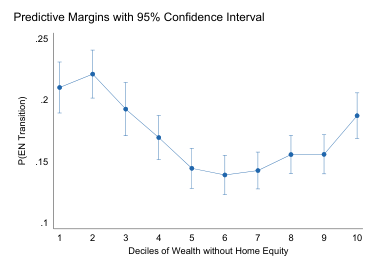

NOTE: figure/graphic rendered as an image from the PDF; its content is not machine-readable text. Caption (if any) follows as the next block.

**text found inside the figure**

.1

.15

.2

.25

P(EN Transition)

1 2 3 4 5 6 7 8 9 10 Deciles of Wealth without Home Equity

Predictive Margins with 95% Confidence Interval

(a) Liquid Wealth

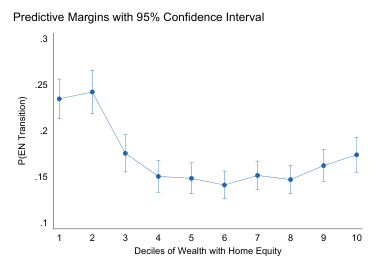

NOTE: figure/graphic rendered as an image from the PDF; its content is not machine-readable text. Caption (if any) follows as the next block.

**text found inside the figure**

.1

.15

.2

.25

.3

P(EN Transition)

1 2 3 4 5 6 7 8 9 10 Deciles of Wealth with Home Equity

Predictive Margins with 95% Confidence Interval

(b) Total Wealth

*Note:* These figures plot the predictive margins on deciles of wealth from an LPM regression as presented in equation 1 with less strict definition of the *ENi*,*t* dummy. Panel B.1a includes deciles of wealth without home equity, whilst Panel B.1b includes deciles of wealth with home equity. Year fixed effects, individual controls and a full set of industry and occupation controls are included. Standard errors are clustered at the individual level. Data is from waves 1999-2017 of the PSID.

30

Page 31

Table B.1: Focusing on the Tails of the Wealth Distribution (alternative definition of *EN*).

|  | WealthwithoutHomeEquity |  |  | WealthwithHomeEquity |  |  |
| --- | --- | --- | --- | --- | --- | --- |
|  | (1) | (2) | (3) | (4) | (5) | (6) |
|  | β/SE | β/SE | β/SE | β/SE | β/SE | β/SE |
| LowWealth | 0058*** 0042*** . . |  | 0044*** . | 0097*** 0067*** . . |  | 0068*** . |
|  | (0011) . | (0011) . | (0011) . | (0011) . | (0011) . | (0011) . |
| HighWealth | 0060*** 0032*** - . . |  | 0030*** . | 0070*** 0023** - . . |  | 0020** . |
|  | (0009) . | (0010) . | (0010) . | (0009) . | (0010) . | (0010) . |
| Observations | 20604 | 19128 | 19051 | 20604 | 19128 | 19051 |
| Individuals | 5008 | 4835 | 4830 | 5008 | 4835 | 4830 |
| R2 | 0007 . | 0065 . | 0078 . | 0012 . | 0066 . | 0079 . |
| YearFE | Yes | Yes | Yes | Yes | Yes | Yes |
| IndividualControls | No | Yes | Yes | No | Yes | Yes |
| Industry/Occupation | No | No | Yes | No | No | Yes |

NOTE: table converted from PDF layout to HTML text; cell boundaries are reconstructed. See PDF if exact alignment matters.

* p *<* 0.1, ** p *<* 0.05, *** p *<* 0.01. Standard errors in parentheses.

*Note:* Standard errors are clustered at the individual level. Low Wealth and High

Wealth correspond to the bottom and the top decile of respective household wealth distribution. Base group is the remainder of the wealth distribution. Individual controls include age, education, female, race, marital status, number of children, hourly wage, and region. Industry and occupation dummies are based on 2-digit classifications.

#### **B.1.2 Wealth Distribution: ranking using household wealth**

We construct the *Low Wealth* and *High Wealth* dummies based on the distribution of per-capita

wealth in the paper. Here we show that under an alternative ranking of workers, one that uses

household wealth instead, the U-shaped relationship between net wealth and *EN*-transitions

prevails, see Figure B.2 and Table B.2.

#### **B.1.3 Sample selection: only including household heads**

In the main body of the paper we included information on household heads and their spouses.

This comes with the advantage of enlarging the sample size. However, some studies that use

PSID data favour to focus on heads of the household only. For the sake of comparability, we

show below that the novel finding on the U-shaped relationship between wealth and propen-

sity to experience an *EN* transition prevails on such more constrained sample.

As the mapping between household net wealth and worker is now one-to-one, we derive

workers’ position on the wealth distribution using household net wealth. Analogously to the

main text, we report results for two measures of net wealth. To begin with, we rerun the

estimation producing Figure 2 in the main text. The results, which are displayed on Figure B.3,

are similar, both qualitatively and quantitatively.

Next, we estimate equation (2) on the sample of household heads and report the results of

doing so in Table B.3. Despite the sample size shrinking significantly, we nevertheless uncover

a pattern strikingly similar to that reported in Table 3.

31

Page 32

Figure B.2: Margins of Deciles of wealth on the probability of an *EN*-transition (household wealth).

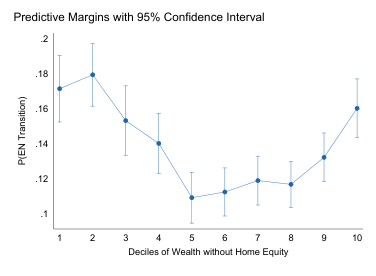

NOTE: figure/graphic rendered as an image from the PDF; its content is not machine-readable text. Caption (if any) follows as the next block.

**text found inside the figure**

.1

.12

.14

.16

.18

.2

P(EN Transition)

1 2 3 4 5 6 7 8 9 10 Deciles of Wealth without Home Equity

Predictive Margins with 95% Confidence Interval

(a) Liquid Wealth

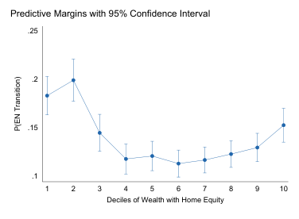

NOTE: figure/graphic rendered as an image from the PDF; its content is not machine-readable text. Caption (if any) follows as the next block.

**text found inside the figure**

.1

.15

.2

.25

P(EN Transition)

1 2 3 4 5 6 7 8 9 10 Deciles of Wealth with Home Equity

Predictive Margins with 95% Confidence Interval

(b) Total Wealth

*Note:* These figures plot the predictive margins on deciles of wealth from an LPM regression as presented in equation 1 with deciles based on household, and not per-capita wealth. Panel B.2a includes deciles of wealth without home equity, whilst Panel B.2b includes deciles of wealth with home equity. Year fixed effects, individual controls and a full set of industry and occupation controls are included. Standard errors are clustered at the individual level. Data is from waves 1999-2017 of the PSID.

Table B.2: Focusing on the Tails of the Wealth Distribution (Household wealth).

|  | WealthwithoutHomeEquity |  |  | WealthwithHomeEquity |  |  |
| --- | --- | --- | --- | --- | --- | --- |
|  | (1) | (2) | (3) | (4) | (5) | (6) |
|  | β/SE | β/SE | β/SE | β/SE | β/SE | β/SE |
| LowWealth | 0046*** 0037*** . . |  | 0039*** . | 0071*** 0048*** . . |  | 0048*** . |
|  | (0010) . | (0010) . | (0010) . | (0011) . | (0010) . | (0010) . |
| HighWealth | 0052*** 0038*** - . . |  | 0035*** . | 0055*** 0034*** - . . |  | 0030*** . |
|  | (0008) . | (0009) . | (0008) . | (0008) . | (0009) . | (0009) . |
| Observations | 20604 | 19128 | 19051 | 20604 | 19128 | 19051 |
| Individuals | 5008 | 4835 | 4830 | 5008 | 4835 | 4830 |
| R2 | 0006 . | 0063 . | 0070 . | 0008 . | 0063 . | 0070 . |
| YearFE | Yes | Yes | Yes | Yes | Yes | Yes |
| IndividualControls | No | Yes | Yes | No | Yes | Yes |
| Industry/Occupation | No | No | Yes | No | No | Yes |

NOTE: table converted from PDF layout to HTML text; cell boundaries are reconstructed. See PDF if exact alignment matters.

* p *<* 0.1, ** p *<* 0.05, *** p *<* 0.01. Standard errors in parentheses.

*Note:* Standard errors are clustered at the individual level. Next to estimates

we report marginal effects evaluated at mean values of other regressors. Low Wealth and High Wealth correspond to the bottom and the top decile of respective household wealth distribution. Base group is the remainder of the wealth distribution. Individual controls include age, education, female, race, marital status, number of children, hourly wage, and region. Industry and occupation dummies are based on 2-digit classifications.

32

Page 33

Figure B.3: Margins of Deciles of wealth on the probability of an *EN*-transition (Heads only).

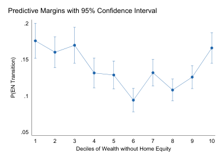

NOTE: figure/graphic rendered as an image from the PDF; its content is not machine-readable text. Caption (if any) follows as the next block.

**text found inside the figure**

.05

.1

.15

.2

P(EN Transition)

1 2 3 4 5 6 7 8 9 10 Deciles of Wealth without Home Equity

Predictive Margins with 95% Confidence Interval

(a) Liquid Wealth

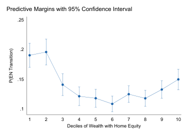

NOTE: figure/graphic rendered as an image from the PDF; its content is not machine-readable text. Caption (if any) follows as the next block.

**text found inside the figure**

.1

.15

.2

.25

P(EN Transition)

1 2 3 4 5 6 7 8 9 10 Deciles of Wealth with Home Equity

Predictive Margins with 95% Confidence Interval

(b) Total Wealth

*Note:* These figures plot the predictive margins on deciles of wealth from an LPM regression as presented in equation 1 ran on a sample of respondents who were classified as head of household. Panel B.3a includes deciles of wealth without home equity, whilst Panel B.3b includes deciles of wealth with home equity. Year fixed effects, individual controls and a full set of industry and occupation controls are included. Standard errors are clustered at the individual level. Data is from waves 1999-2017 of the PSID.

Table B.3: Focusing on the Tails of the Wealth Distribution (Heads only).

|  | WealthwithoutHomeEquity |  |  | WealthwithHomeEquity |  |  |
| --- | --- | --- | --- | --- | --- | --- |
|  | (1) | (2) | (3) | (4) | (5) | (6) |
| LowWealth | 0059*** 0043*** . . |  | 0045*** . | 0078*** 0051*** . . |  | 0053*** . |
|  | (0013) . | (0013) . | (0013) . | (0014) . | (0013) . | (0013) . |
| HighWealth | 0049*** 0046*** - . . |  | 0042*** . | 0057*** 0036*** - . . |  | 0030*** . |
|  | (0010) . | (0011) . | (0011) . | (0009) . | (0011) . | (0011) . |
| Observations | 13616 | 12565 | 12516 | 13616 | 12565 | 12516 |
| Individuals | 3551 | 3423 | 3418 | 3551 | 3423 | 3418 |
| R2 | 0008 . | 0073 . | 0081 . | 0010 . | 0073 . | 0081 . |
| YearFE | Yes | Yes | Yes | Yes | Yes | Yes |
| IndividualControls | No | Yes | Yes | No | Yes | Yes |
| Industry/Occupation | No | No | Yes | No | No | Yes |

NOTE: table converted from PDF layout to HTML text; cell boundaries are reconstructed. See PDF if exact alignment matters.

* p *<* 0.1, ** p *<* 0.05, *** p *<* 0.01. Standard errors in parentheses.

*Note:* Standard errors are clustered at the individual level. Next to estimates

we report marginal effects evaluated at mean values of other regressors. Low Wealth and High Wealth correspond to the bottom and the top decile of respective wealth distribution. Base group is the remainder of the wealth distribution. Individual controls include age, education, female, race, marital status, number of children, hourly wage, and region. Industry and occupation dummies are based on 2-digit classifications.

#### **B.1.4 Alternative estimators: probit & logit**

Our main variable of interest is the probability of a worker experiencing an *EN*-transition, as

defined in the main text of the paper. The linear probability model, understandably, is poten-

33

Page 34

tially misspecified because it can predict values of this probability falling outside of the [0, 1] range. To address this concern, we investigate the dependence of the probability of an *EN*-

transition on wealth estimating probit and logit specification. The results, reported in Figures

B.4 and B.5 and Tables B.4 and B.5 again indicate that the relationship of interest is a U-shaped

one. The linear probability model only mildly overestimates the marginal effect of being in

either *Low Wealth* or *High Wealth* bin on *EN*-transition. To see this, compare, for example, col-

umn (3) in Table 3 with tables reported here. In the main text, the estimated coefficients for

Figure B.4: Margins of Deciles of wealth on the probability of an *EN*-transition (Probit).

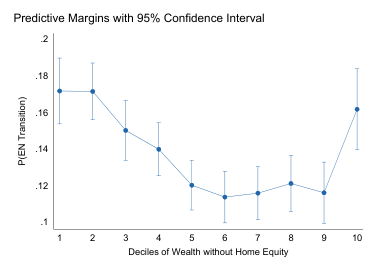

NOTE: figure/graphic rendered as an image from the PDF; its content is not machine-readable text. Caption (if any) follows as the next block.

**text found inside the figure**

.1

.12

.14

.16

.18

.2

P(EN Transition)

1 2 3 4 5 6 7 8 9 10 Deciles of Wealth without Home Equity

Predictive Margins with 95% Confidence Interval

(a) Liquid Wealth

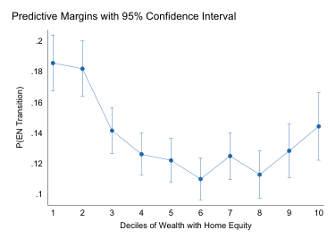

NOTE: figure/graphic rendered as an image from the PDF; its content is not machine-readable text. Caption (if any) follows as the next block.

**text found inside the figure**

.1

.12

.14

.16

.18

.2

P(EN Transition)

1 2 3 4 5 6 7 8 9 10 Deciles of Wealth with Home Equity

Predictive Margins with 95% Confidence Interval

(b) Total Wealth

*Note:* These figures plot the predictive margins on deciles of wealth from a probit regression as presented in equation 1. Panel B.4a includes deciles of wealth without home equity, whilst Panel B.4b includes deciles of wealth with home equity. Year fixed effects, individual controls and a full set of industry and occupation controls are included. Standard errors are clustered at the individual level. Data is from waves 1999-2017 of the PSID.

#### **B.1.5 Alternative definition of the *Low Wealth* dummy**

The U-shape relationship between per-capita wealth, visualised on Figure 2 in the main text

can be considered asymmetric. The lowest two deciles of the net wealth distributions exhibit

markedly higher incidence of *EN*-transitions than the rest of the distribution. In the paper, we

specified the *Low Wealth* and *High Wealth* dummies to correspond to the bottom and the top

decile, respectively. We now show that this was indeed a conservative choice.

Comparing the coefficients reported in columns (3) and (6) of Tables 3 and B.6 we find

that the coefficients in the latter on both *High Wealth* and *Low Wealth* increase while remaining

statistically significantly different from zero. This confirms that the definition of the *Low Wealth*

dummy led to us underestimating the strength of the U-shape relationship.

34

Page 35

Table B.4: Focusing on the Tails of the Wealth Distribution (Probit).

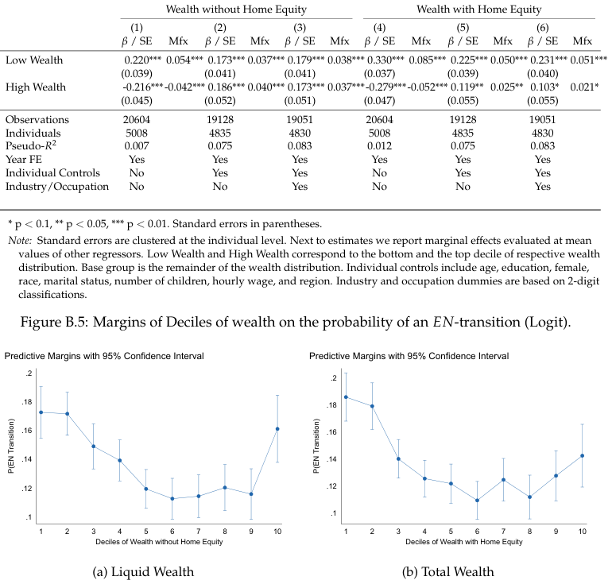

NOTE: complex table shown as an image of the PDF; the text below is a rough machine extraction and may be mis-aligned.

**extracted text (unreliable layout)**

*Note:* These figures plot the predictive margins on deciles of wealth from a logit regression as presented in equation 1. Panel B.5a includes deciles of wealth without home equity, whilst Panel B.5b includes deciles of wealth with home equity. Individual controls and a full set of industry and occupation controls are included. Standard errors are clustered at the individual level. Data is from waves 1999-2017 of the PSID.

**B.2 Relationship between wealth and** *EN***,** *EE***, and** *NE* **transitions.**

We now show that the U-shape dependence on wealth is a unique feature of *EN* transitions. To

this end, we collect data on *EE* transitions (Employment-to-Employment) and on *NE* transi-

tions (Non-employment-to-Employment). We identify *EE* transitions following the procedure

that leads to detection of *E*(*N*)*E* transitions. The difference here is that we set *EEi*,*t* = 1 for

workers who report being employed at the current interview date, report employment at a

new job at the next interview and do not report any non-employment between interviews. We

set *EEi*,*t* = 0 for all other workers who are employed at the current and at the next interview

date.

35

Page 36

Table B.5: Focusing on the Tails of the Wealth Distribution (Logit).

|  | WealthwithoutHomeEquity |  | WealthwithHomeEquity |  |
| --- | --- | --- | --- | --- |
|  | (1) (2) | (3) | (4) (5) | (6) |
|  | β/SE Mfx β/SE | Mfx β/SE Mfx | β/SE Mfx β/SE Mfx | β/SE Mfx |
| LowWealth | 0397*** 0054*** 0322***0036***0333***0037***0590*** 0085*** 0409***0048***0421***0049*** . . . . . . . . . . . . |  |  |  |
|  | (0069) (0074) . . | (0074) . | (0065) (0069) . . | (0069) . |
| HighWealth | 0412*** 0042***0322***0036***0309***0034*** 0539*** 0052***0194* 0021* - . - . . . . . - . - . . . |  |  | 0172 0018 . . |
|  | (0087) (0098) . . | (0098) . | (0092) (0106) . . | (0106) . |
| Observations | 20604 19128 | 19051 | 20604 19128 | 19051 |
| Individuals | 5008 4835 | 4830 | 5008 4835 | 4830 |
| Pseudo-R2 | 0007 0076 . . | 0084 . | 0012 0077 . . | 0084 . |
| YearFE | Yes Yes | Yes | Yes Yes | Yes |
| IndividualControls | No Yes | Yes | No Yes | Yes |
| Industry/Occupation | No No | Yes | No No | Yes |

NOTE: table converted from PDF layout to HTML text; cell boundaries are reconstructed. See PDF if exact alignment matters.

* p *<* 0.1, ** p *<* 0.05, *** p *<* 0.01. Standard errors in parentheses.

*Note:* Standard errors are clustered at the individual level. Next to estimates we report marginal effects evaluated at mean

values of other regressors. Low Wealth and High Wealth correspond to the bottom and the top decile of respective wealth distribution. Base group is the remainder of the wealth distribution. Individual controls include age, education, female, race, marital status, number of children, hourly wage, and region. Industry and occupation dummies are based on 2-digit classifications.

Table B.6: Focusing on the Tails of the Wealth Distribution (*Low Wealth* as bottom 2 deciles).

|  | WealthwithoutHomeEquity |  |  | WealthwithHomeEquity |  |  |
| --- | --- | --- | --- | --- | --- | --- |
|  | (1) | (2) | (3) | (4) | (5) | (6) |
|  | β/SE | β/SE | β/SE | β/SE | β/SE | β/SE |
| LowWealth | 0084*** 0051*** . . |  | 0050*** . | 0123*** 0071*** . . |  | 0069*** . |
|  | (0008) . | (0007) . | (0007) . | (0008) . | (0008) . | (0008) . |
| HighWealth | 0029*** 0044*** - . . |  | 0041*** . | 0036*** 0031*** - . . |  | 0027*** . |
|  | (0008) . | (0009) . | (0009) . | (0008) . | (0009) . | (0009) . |
| Observations | 20604 | 19128 | 19051 | 20604 | 19128 | 19051 |
| Individuals | 5008 | 4835 | 4830 | 5008 | 4835 | 4830 |
| R2 | 0013 . | 0065 . | 0072 . | 0023 . | 0067 . | 0074 . |
| YearFE | Yes | Yes | Yes | Yes | Yes | Yes |
| IndividualControls | No | Yes | Yes | No | Yes | Yes |
| Industry/Occupation | No | No | Yes | No | No | Yes |

NOTE: table converted from PDF layout to HTML text; cell boundaries are reconstructed. See PDF if exact alignment matters.

* p *<* 0.1, ** p *<* 0.05, *** p *<* 0.01. Standard errors in parentheses.

*Note:* Standard errors are clustered at the individual level. Low Wealth corre-

sponds to the bottom two deciles and High Wealth to the top decile of respective wealth distribution. Base group is the remainder of the wealth distribution. Individual controls include age, education, female, race, marital status, number of children, hourly wage, and region. Industry and occupation dummies are based on 2-digit classifications.

The construction of the *NEi*,*t* dummy is the exact opposite of the *EI* and *EU* transitions. We

set *NEi*,*t* = 1 if a worker reports being non-employed at current interview and is found to be

employed at the next interview date. Note, because of how survey is constructed, we do not

observe *N*(*E*)*N* transitions as non-employed workers are not asked about employment spells

between interview dates.

36

Page 37

Figure B.6 presents the results of an exercise analogous to that presented on Figure 2 in the

main body of the paper but with the probability of experiencing an *EE* transition as the depen-

dent variable. Here, we do not see a U-shaped pattern, but a clear evidence of the likelihood

of experiencing an *EE* transition to decline in wealth.

Figure B.6: Margins of Deciles of wealth on the probability of an EE-Transition

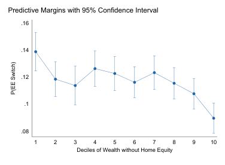

NOTE: figure/graphic rendered as an image from the PDF; its content is not machine-readable text. Caption (if any) follows as the next block.

**text found inside the figure**

.08

.1

.12

.14

.16

P(EE Switch)

1 2 3 4 5 6 7 8 9 10 Deciles of Wealth without Home Equity

Predictive Margins with 95% Confidence Interval

(a)

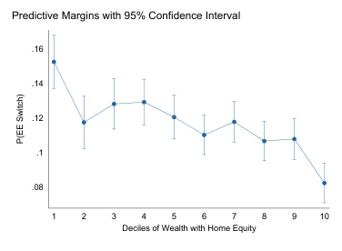

NOTE: figure/graphic rendered as an image from the PDF; its content is not machine-readable text. Caption (if any) follows as the next block.

**text found inside the figure**

.08

.1

.12

.14

.16

P(EE Switch)

1 2 3 4 5 6 7 8 9 10 Deciles of Wealth with Home Equity

Predictive Margins with 95% Confidence Interval

(b)

*Note:* These figures plot the predictive margins on deciles of wealth from a linear probability model regression as presented in equation 1 with the *EEit* dummy as the dependent variable. . Panel 2a includes deciles of wealth without home equity, whilst Panel 2b includes deciles of wealth with home equity. Year fixed effects, individual controls and a full set of industry and occupation controls are included. Standard errors are clustered at the individual level. Data is from waves 1999-2017 of the PSID.

Figure B.7 presents the results of an exercise analogous to that presented on Figure 2 in

Figure B.7: Margins of Deciles of wealth on the probability of an NE-Transition

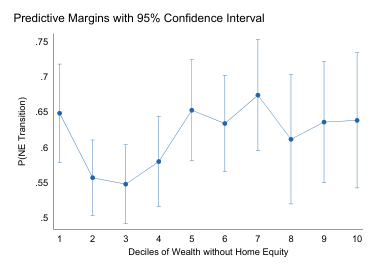

NOTE: figure/graphic rendered as an image from the PDF; its content is not machine-readable text. Caption (if any) follows as the next block.

**text found inside the figure**

.5

.55

.6

.65

.7

.75

P(NE Transition)

1 2 3 4 5 6 7 8 9 10 Deciles of Wealth without Home Equity

Predictive Margins with 95% Confidence Interval

(a)

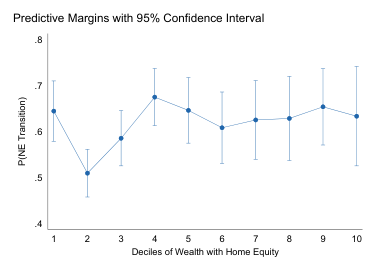

NOTE: figure/graphic rendered as an image from the PDF; its content is not machine-readable text. Caption (if any) follows as the next block.

**text found inside the figure**

.4

.5

.6

.7

.8

P(NE Transition)

1 2 3 4 5 6 7 8 9 10 Deciles of Wealth with Home Equity

Predictive Margins with 95% Confidence Interval

(b)

*Note:* These figures plot the predictive margins on deciles of wealth from a linear probability model regression as presented in equation 1 with the *NEit* dummy as the dependent variable. . Panel 2a includes deciles of wealth without home equity, whilst Panel 2b includes deciles of wealth with home equity. Year fixed effects, individual controls and a full set of industry and occupation controls are included. Standard errors are clustered at the individual level. Data is from waves 1999-2017 of the PSID.

37

Page 38

Finally, we make a more formal comparison in Table B.7. Columns (1) and (4) repeat the

result from the main text. Columns (2) and (5) are concerned with the effect of *Low Wealth*

and *High Wealth* on *NE*-transitions. While the estimated coefficients are positive, they are not

significantly different from zero. Finally, we find a starkly different pattern in columns (3)

and (6), the likelihood of experiencing an *EE*-transition is found to decline significantly with

wealth.

Table B.7: Focusing on the Tails of the Wealth Distribution: *EN* versus *EE* and *NE*.

|  | WealthwithoutHomeEquity |  | WealthwithHomeEquity |  |  |
| --- | --- | --- | --- | --- | --- |
|  | (1) | (2) (3) | (4) | (5) | (6) |
|  | EN | NE EE | EN | NE | EE |
| LowWealth | 0040*** 0052 0028*** . . . |  | 0056*** 0051 . . |  | 0030*** . |
|  | (0010) . | (0037) (0009) . . | (0011) . | (0035) . | (0010) . |
| HighWealth | 0037*** 0028 0022*** . . - . |  | 0025*** 0015 . . |  | 0026*** - . |
|  | (0009) . | (0050) (0007) . . | (0009) . | (0056) . | (0007) . |
| Observations | 19051 | 2077 19051 | 19051 | 2077 | 19051 |
| Individuals | 4830 | 1223 4830 | 4830 | 1223 | 4830 |
| R2 | 0070 . | 0065 0046 . . | 0070 . | 0065 . | 0046 . |
| YearFE | Yes | Yes Yes | Yes | Yes | Yes |
| IndividualControls | Yes | Yes Yes | Yes | Yes | Yes |
| Industry/Occupation | Yes | Yes Yes | Yes | Yes | Yes |

NOTE: table converted from PDF layout to HTML text; cell boundaries are reconstructed. See PDF if exact alignment matters.

* p *<* 0.1, ** p *<* 0.05, *** p *<* 0.01. Standard errors in parentheses.

*Note:* Standard errors are clustered at the individual level. Low Wealth and High

Wealth correspond to the bottom and the top decile of respective wealth distribution. Base group is the remainder of the wealth distribution. Individual controls include age, education, female, race, marital status, number of children, hourly wage, and region. Industry and occupation dummies are based on 2- digit classifications.

#### **B.3 Additional Tables and Figures**

**Life-Cycle** We re-estimate specification (2) for subsamples of different ages, taking five year

age bins from age 20 to 65. We plot the results in Figure B.8, with panel (a) comparing the

estimated *EN* probabilities for the bottom decile with the middle deciles, and panel (b) doing

the same for the top decile. The general pattern conveyed by the figures is that the excess *EN*

rate of the bottom and top wealth deciles is present across most of the age distribution. The

figures reveal that the *EN* rate is declining for all wealth deciles as workers age, as is to be

expected. At every wealth decile the point estimate for the bottom and top deciles is greater

than the middle deciles, as with our main finding. As workers age the gap shrinks, and the

for the oldest workers.

38

Page 39

Figure B.8: *EN* Transitions across the Life-cycle

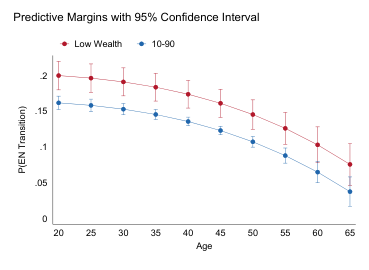

NOTE: figure/graphic rendered as an image from the PDF; its content is not machine-readable text. Caption (if any) follows as the next block.

**text found inside the figure**

0

.05

.1

.15

.2

P(EN Transition)

20 25 30 35 40 45 50 55 60 65 Age

Low Wealth 10-90

Predictive Margins with 95% Confidence Interval

(a) Bottom 10% vs. 10-90%

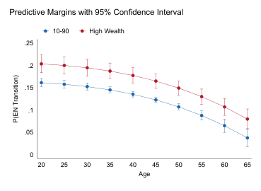

NOTE: figure/graphic rendered as an image from the PDF; its content is not machine-readable text. Caption (if any) follows as the next block.

**text found inside the figure**

0

.05

.1

.15

.2

.25

P(EN Transition)

20 25 30 35 40 45 50 55 60 65 Age

10-90 High Wealth

Predictive Margins with 95% Confidence Interval

(b) Top 10% vs. 10-90%

*Note:* These figures plot the predictive margins on deciles of wealth from a regression as presented in equation 1 with the corresponding 95% confidence interval. Where the dependent variable is whether respondent experienced an *EN* switch, but for the margins across age groups. Panel B.8a compares the bottom 10% of the wealth distribution to the centre and Panel B.8b compares the top 10% of the distribution to the centre. Individual controls and a full set of industry and occupation controls are included. Standard errors are clustered at the individual level.

39